# Personality and music taste

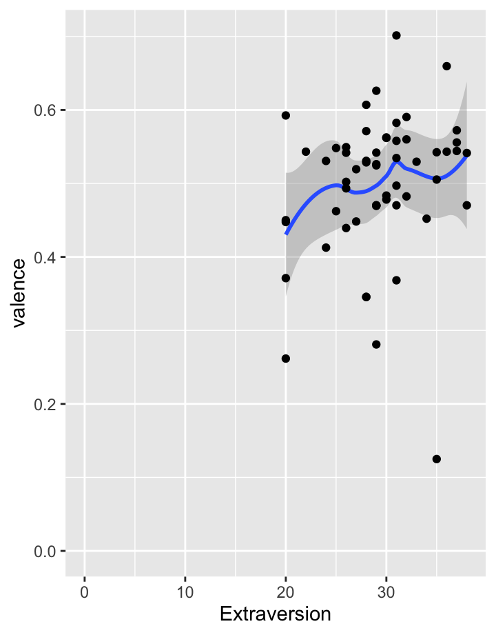

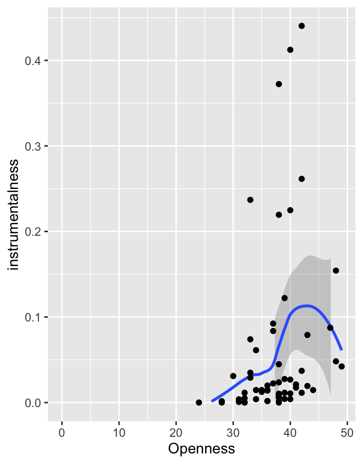

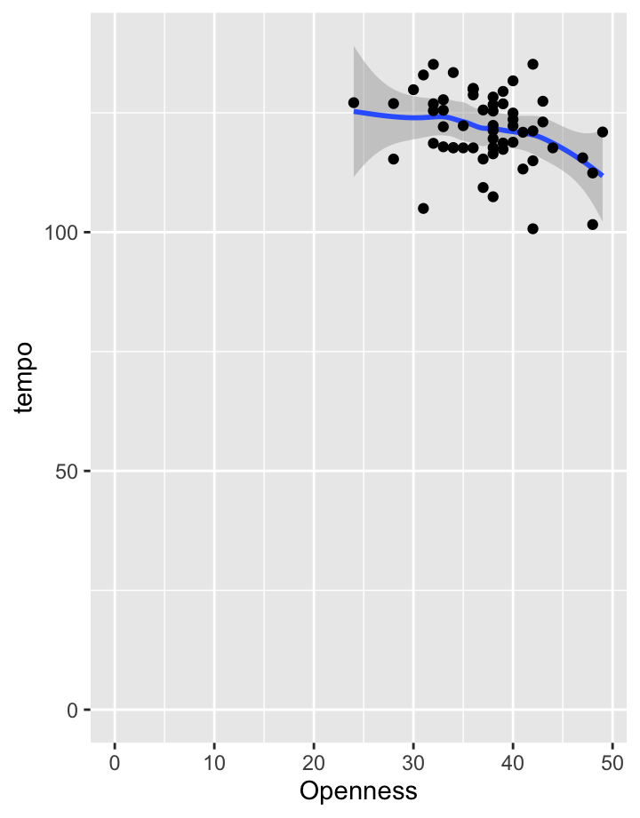

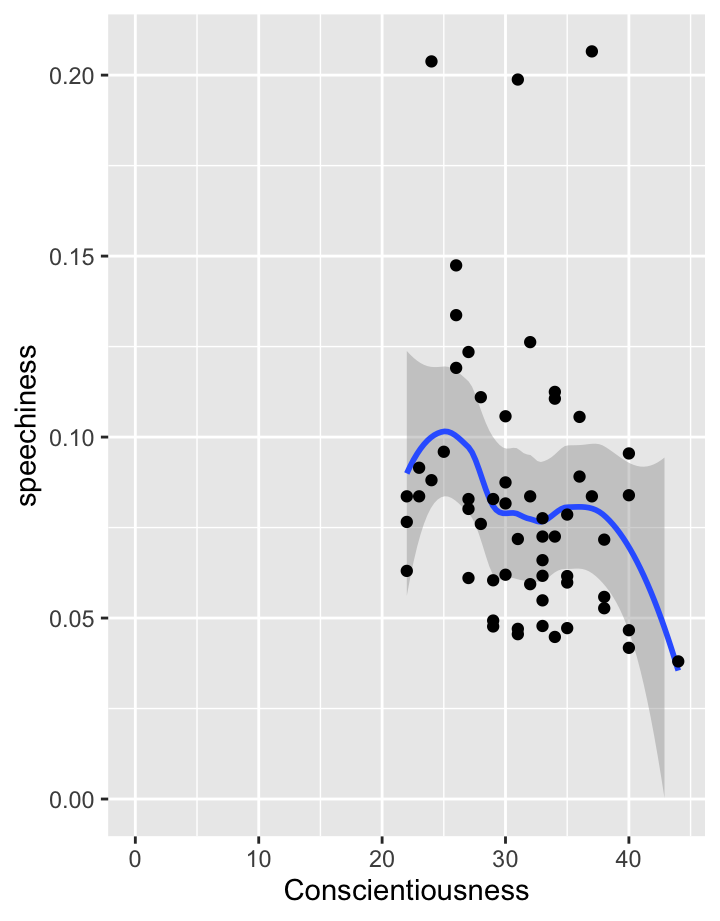

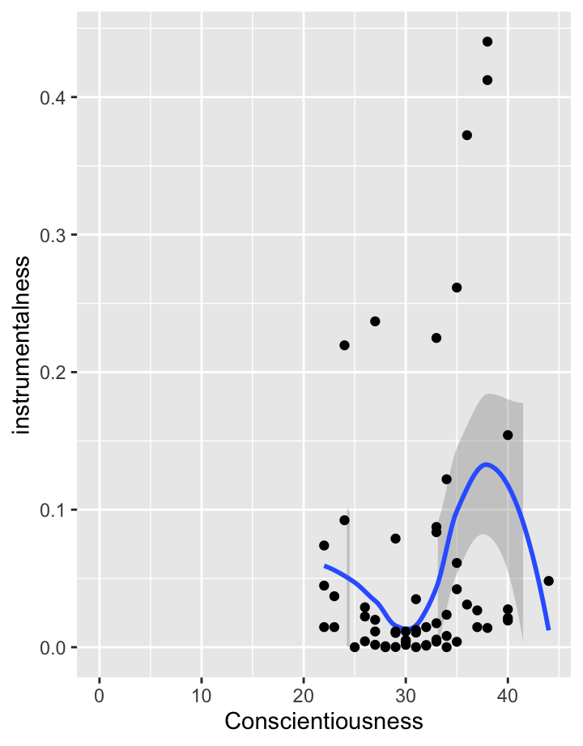

[figure not shown]

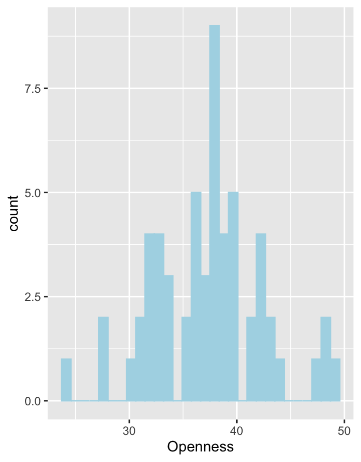

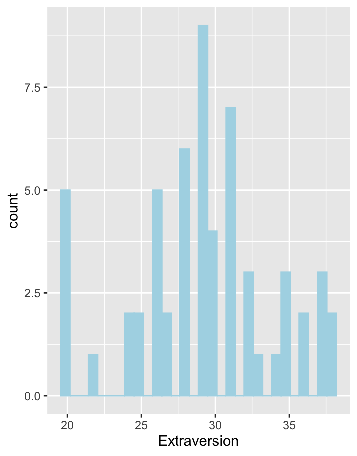

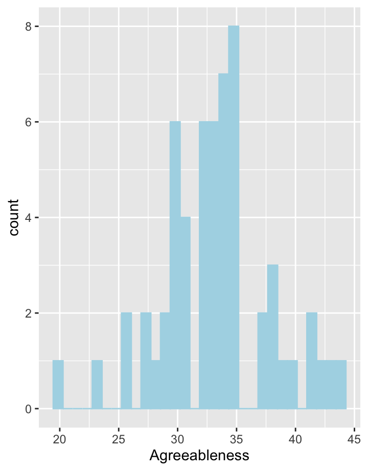

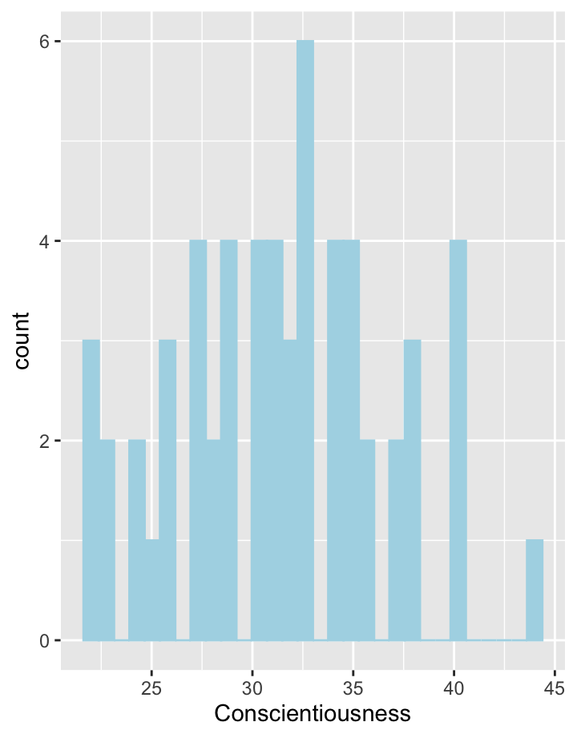

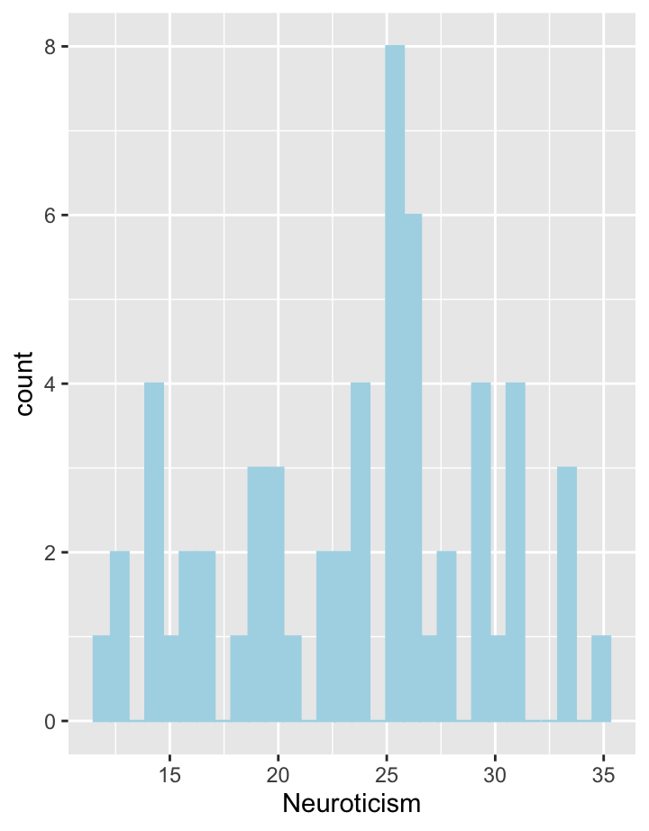

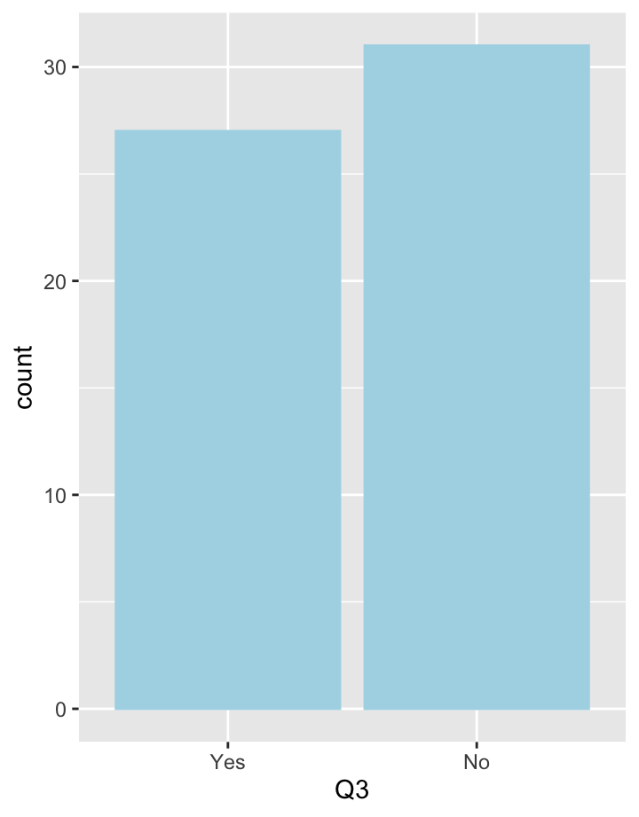

# Intro

#### Introduction

Music taste is deeply personal and can be traced back to many aspects of a person’s life. It is deeply intertwined with both internal and external processes a person goes through. It can be considered a mysterious, even mystical, topic. Nevertheless, it has been a topic that researchers have been trying to demystify and generate theories about. Previous research has shown that there is a consistent relationship between personality and musical preference (Dunn et al., 2011). Personality has proven to be a key in understanding the structure of music preference. The correlations that have been found inspired us to set up our own research to investigate this relationship. In our research, we have tried to answer the question ‘What is the influence of someone’s personality on their music taste?’.

### Valuebox

58

### Valuebox

44

### Valuebox

30

### Extraversion vs valence

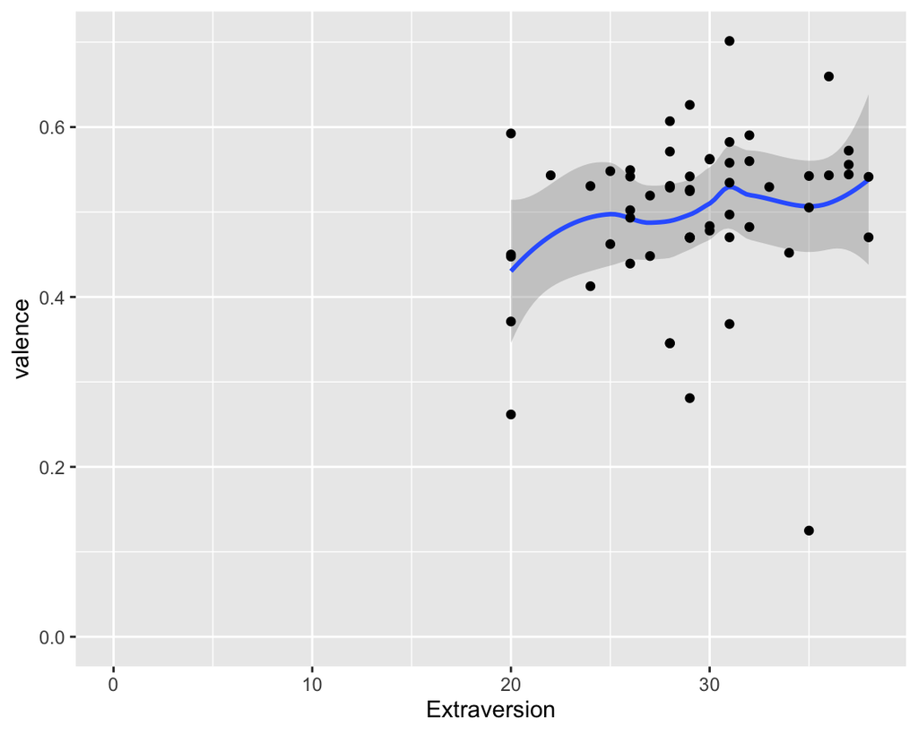

### Motivation

During the brainstorm sessions we almost immediately came to the conclusion that we wanted to include personality into our research question. For example, we all know someone who is really exuberant and likes to listen to cheerful and elated music. This made us wonder if there could be a correlation between this. This is why we wanted to do an experiment to find out the correlation between personality and music preferences. Previous investigations on the relation between music taste and personality were largely based on self-developed models of musical preference (Dunn et al., 2011). These models mainly relied on individuals’ self-reports to measure and define their musical preference, meaning that they were based on subjective models. ‘Objective’ tools such as the Spotify API were rarely used. We expect our research to contribute new insights, because the methods we have used can be regarded as more objective than previous measurements of musical preference.

### The graph

# Main correlations & Method

### Method

To qualify the personalities of the participants, we used the big five personality traits. This trait theory, developed in the 1980’s, divides personalities in five groups. These groups are openness to experience, conscientiousness, extraversion, agreeableness & neuroticism (Roccas et al., 2002). We used the big five inventory (bfi) from the Fetzer Institute (John & Srivastava, 1999). This questionnaire consists of 44 questions in the form of: “I see myself as someone who: is talkative” with a scale going from disagree strongly to agree strongly. The 44 questions can be divided into the five personality traits. After asking these 44 questions, the subjects were asked to submit their “on repeat” playlist from spotify. With these playlists, we could examine people’s music taste. To do this, we used the audio features of Spotify API. Spotify API is a software intermediary which enables R Studio and Spotify to communicate with each other. The API provides many audio features of tracks on Spotify. Music taste can be a tricky subject to scientifically research. Genres are often linked to music taste. However, assigning one genre to someone’s entire body of musical preference can hardly be representative. The outline provided by Spotify API was a general, but factual body to gather out data from music tracks from. The audio features provided information that we could link to our participants’ music taste.

Only people who used Spotify could participate in this research and we did not differentiate between people who have their own Spotify account and people who share the same account with friends or family.

### Openness vs instrumentalness

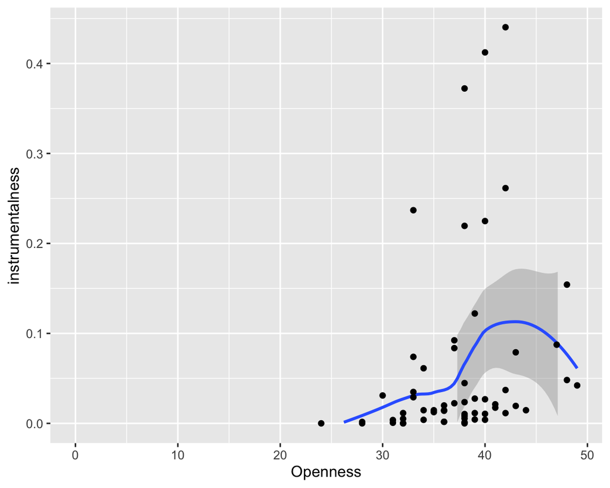

> This graph shows that there is correlation between openness and instrumentalness. Participants of the research who claimed to be open, mostly have songs with more instrumentals in their playlists.

### Openness vs tempo

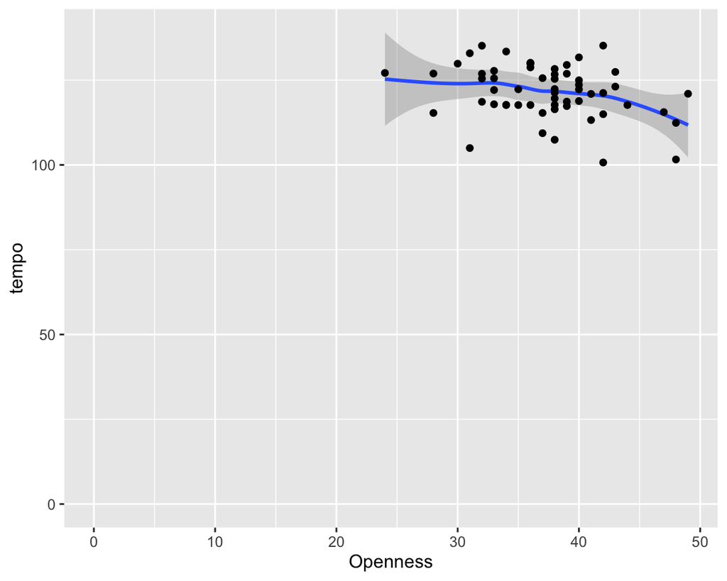

> This graph shows that there is negative correlation between openness and tempo. Participants of the research who claimed to be open, mostly have songs with a lower tempo in their playlists.

### Conscientiousness vs speechiness

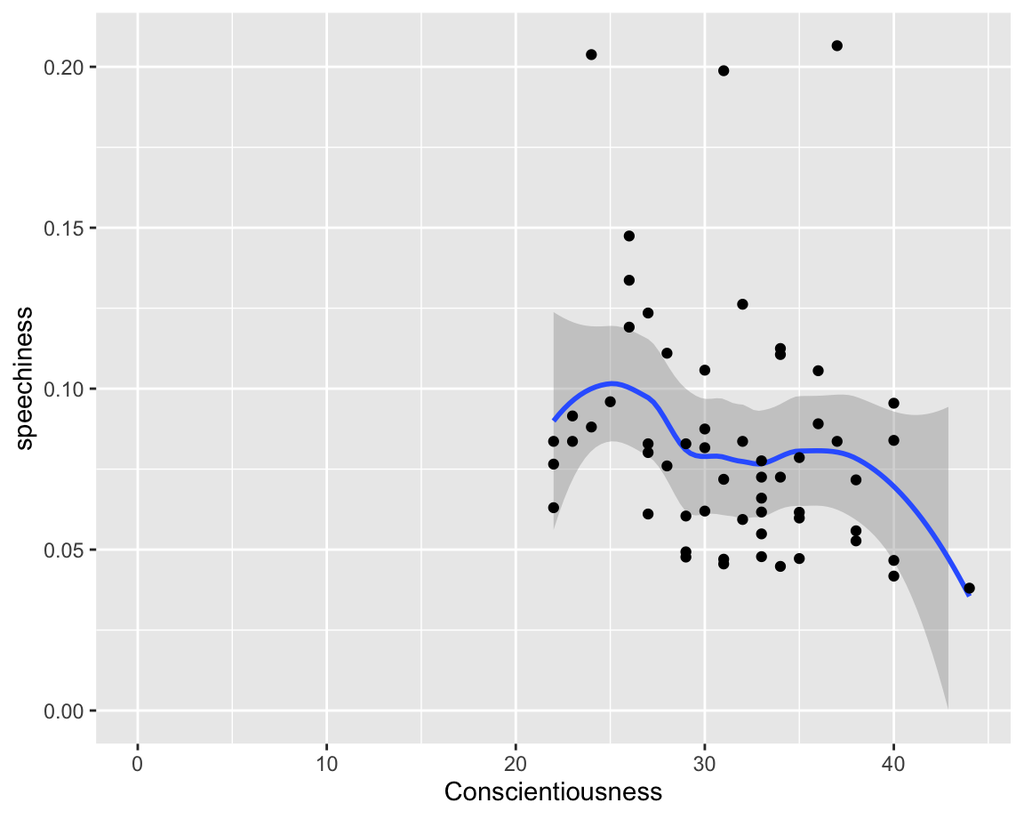

> This graph shows that there is negative correlation between conscientiousness and speechiness. Participants of the research who claimed to be conscient, mostly have songs with less speech in their playlists.

### Conscientiousness vs instrumentalness

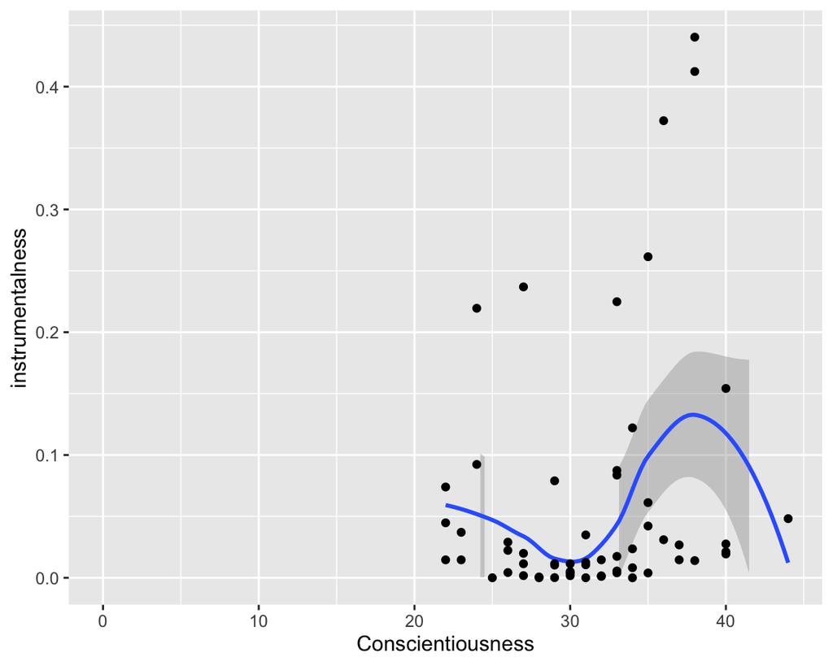

> This graph shows that there is correlation between conscientiousness and instrumentalness. Participants of the research who claimed to be conscient, mostly have songs with more instrumentals in their playlists.

# Correlations

### Correlations

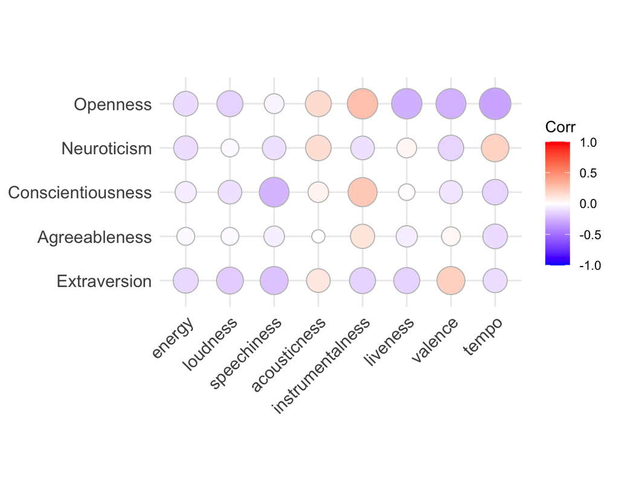

### About the correlations

To discover correlations in the data, we calculated Spearman’s rank correlation coefficient between the audio features and the personality traits. Spearman’s correlation metric differs from the Pearson correlation by being applicable to non-linear monotonic relationships. This is important, because it is very likely that our relationships are not entirely linear.

As expected, most variables had negligible correlations with each other, but there are some more significant correlations. The largest correlation is between openness and tempo (with ρ = -0.31). The smallest correlation is between acousticness and agreeableness (with ρ = -0.001). Some audio features, such as instrumentalness, correlate weakly with all the traits, while others, such as liveness, only correlates significantly with one or two traits.

# Personality-scores

### Openness

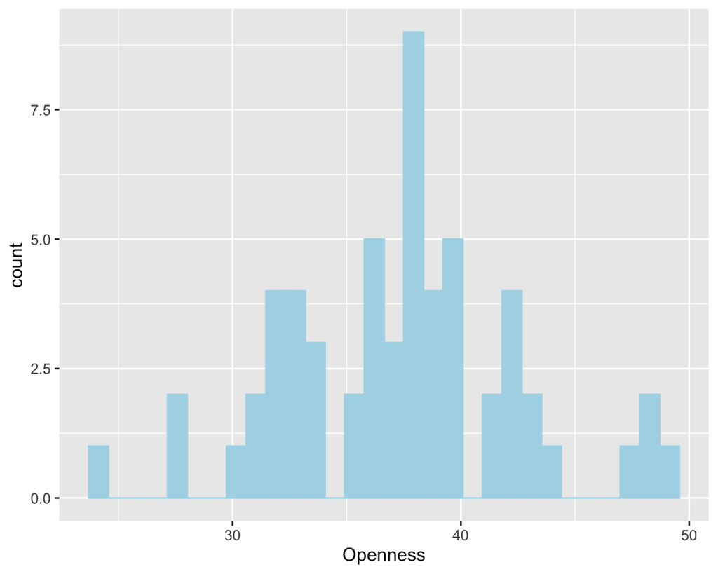

### Extraversion

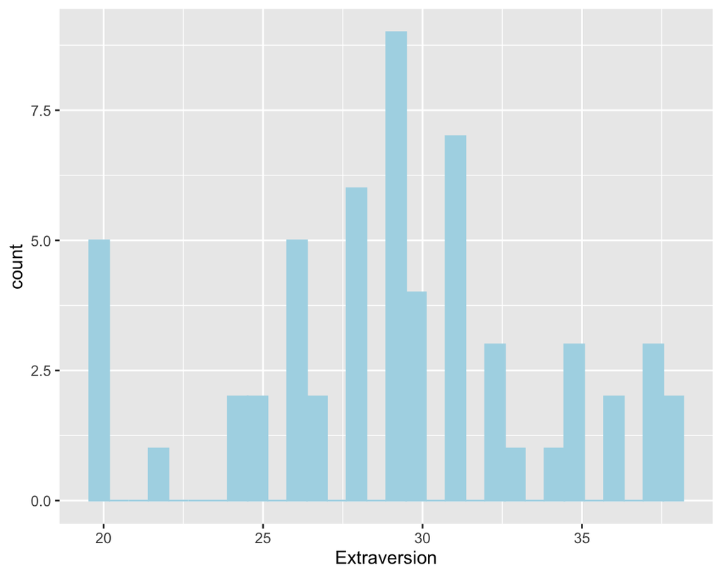

### Agreeableness

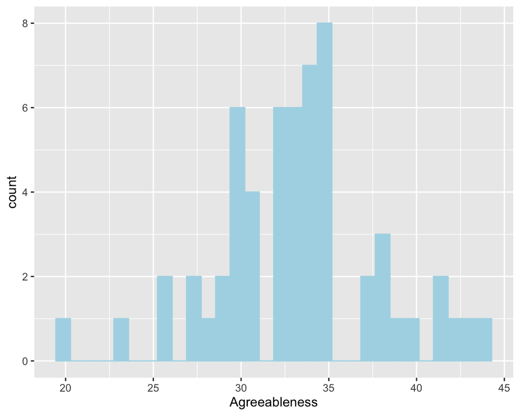

### Conscientiousness

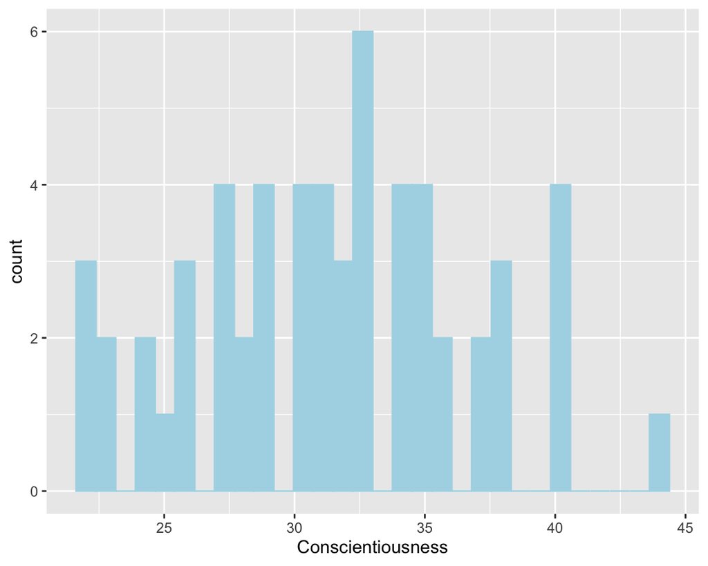

### Neuroticism

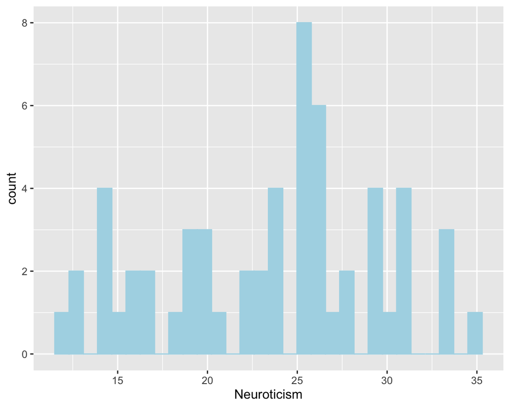

### Personality scores

The questions from the questionnaire can be divided into the five personality traits in the following way where each question could get a maximum of 5 points:

Extraversion: 1, 6R, 11, 16, 21R, 26, 31R, 36

Agreeableness: 2R, 7, 12R, 17, 22, 27R, 32, 37R, 42

Conscientiousness: 3, 8R, 13, 18R, 23R, 28, 33, 38, 43R

Neuroticism: 4, 9R, 14, 19, 24R, 29, 34R, 39

Openness: 5, 10, 15, 20, 25, 30, 35R, 40, 41R, 44

“R” denotes reverse-scored items (John et al., 1999)

The questions for one personality trait are added up. Each personality trait consists of 8 to 10 questions, therefore the maximum score is different for each of them. The graphs seem normal distributed in general, but it is not possible to say that because of the low number of participants.

### Participants with shared spotify account

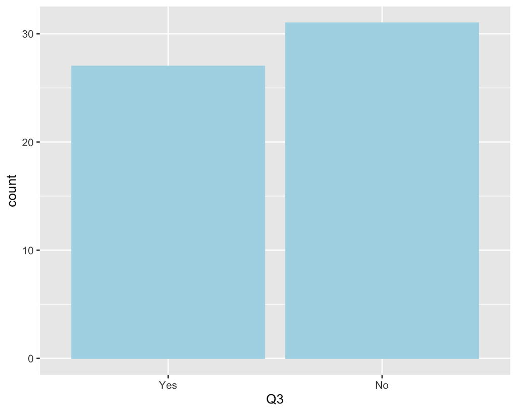

### Participants

In total, 129 people took the survey. From these 129 people, 71 people did not include their Spotify playlist in the survey. They either did not use Spotify or did not share the link. We could not use all links submitted and not everyone filled in all questions. We ended up with 58 usable surveys. Of these 58 surveys 31 did not share their Spotify account with anyone else.

# Conclusion & Discussion

### Conclusion & Discussion

The most significant correlation we have found is between openness and tempo. This was a correlation from -0.3. This means that there is not a very prevalent correlation in our research. This could have been due to the points we have written in our discussion. A suggestion for future research due to these limitations and obstacles, is to use a more accurate questionnaire to gather data on the spotify playlists of our participants. For example to filter out the lists of people who have a shared spotify account. It would also be helpful to gather more data in general, so to send out questionnaires. The last suggestion would be to use other Spotify playlists like ‘rewind’ or, if possible in the future, to use the Spotify wrapped list. This list gives an overview of the entire year of someone’s listening history, which can provide a lot of data on someone’s music preference.

Furthermore, there are some limitations. it is questionable how accurate the Spotify API is. The API can adequately determine parameters like bpm (beats per minute), length or loudness of a song. Parameters like valence (how positive or negative a song is) (Web API Reference | Spotify for Developers, z.d.) are however more difficult to extract from the songs. How positive or negative a song sounds is moreover different per individual.

Besides that, it is doubtful whether people really know themselves. The questionnaire consists of some in depth questions about people’s personality and how they for example interact with other people. Did people purely use their own view about themselves, or were the answers also influenced by things people said to them in the past or even how they felt at the moment of filling in the questionnaire?

The questionnaire consists of 44 questions, in which the nuance of the questions is important. This could be difficult for non-native English speakers. Some people might not have fully understood some words. This could lead to a personality score which is not fully corresponding with the actual personality.

# Background

### Questionnaire

| Number | Statement |
| --- | --- |
| 1 | I see myself as someone who - Is talkative |
| 2 | I see myself as someone who - Tends to find fault with others |
| 3 | I see myself as someone who - Does a thorough job |
| 4 | I see myself as someone who - Is depressed, blue |
| 5 | I see myself as someone who - Is original, comes up with new ideas |
| 6 | I see myself as someone who - Is reserved |
| 7 | I see myself as someone who - Is helpful and unselfish with others |
| 8 | I see myself as someone who - Can be somewhat careless |
| 9 | I see myself as someone who - Is relaxed, handles stress well |
| 10 | I see myself as someone who - Is curious about many different things |
| 11 | I see myself as someone who - Is full of energy |
| 12 | I see myself as someone who - Starts quarrels with others |
| 13 | I see myself as someone who - Is a reliable worker |
| 14 | I see myself as someone who - Can be tense |
| 15 | I see myself as someone who - Is ingenious, a deep thinker |
| 16 | I see myself as someone who - Generates a lot of enthusiasm |
| 17 | I see myself as someone who - Has a forgiving nature |
| 18 | I see myself as someone who - Tends to be disorganized |
| 19 | I see myself as someone who - Worries a lot |
| 20 | I see myself as someone who - Has an active imagination |
| 21 | I see myself as someone who - Tends to be quiet |
| 22 | I see myself as someone who - Is generally trusting |
| 23 | I see myself as someone who - Tends to be lazy |
| 24 | I see myself as someone who - Is emotionally stable, not easily upset |
| 25 | I see myself as someone who - Is inventive |
| 26 | I see myself as someone who - Has an assertive personality |
| 27 | I see myself as someone who - Can be cold and aloof |
| 28 | I see myself as someone who - Perseveres until the task is finished |
| 29 | I see myself as someone who - Can be moody |
| 30 | I see myself as someone who - Values artistic, aesthetic experiences |
| 31 | I see myself as someone who - Is sometimes shy, inhibited |
| 32 | I see myself as someone who - Is considerate and kind to almost everyone |
| 33 | I see myself as someone who - Does things efficiently |
| 34 | I see myself as someone who - Remains calm in tense situations |
| 35 | I see myself as someone who - Prefers work that is routine |
| 36 | I see myself as someone who - Is outgoing, sociable |
| 37 | I see myself as someone who - Is sometimes rude to others |
| 38 | I see myself as someone who - Makes plans and follows through with them |
| 39 | I see myself as someone who - Gets nervous easily |
| 40 | I see myself as someone who - Likes to reflect, play with ideas |
| 41 | I see myself as someone who - Has few artistic interests |
| 42 | I see myself as someone who - Likes to cooperate with others |
| 43 | I see myself as someone who - Is easily distracted |
| 44 | I see myself as someone who - Is sophisticated in art, music, or literature |

### References

Doornekamp, J. 2019 Dit zijn Spotify’s nieuwe gepersonaliseerde afspeellijsten. https://computertotaal.nl/artikelen/apps-software/waarom-dit-je-nieuwe-favoriete-spotify-lijs ten-worden/ (01/02/2022)

Dunn, Greg ; Ruyter, de, B.E.R ; Bouwhuis, D.G 2011 Toward a better understanding of the relation between music preference, listening behavior, and personality. SAGE Publications Psychology of music, 2012, Vol.40 (4), p.411-428. London, England:

John, O. P., & Srivastava, S. 1999 The Big-Five trait taxonomy: History, measurement, and theoretical perspectives. In L. A. Pervin & O. P. John (Eds.), Handbook of personality: Theory and research (Vol. 2, pp. 102–138). New York: Guilford Press.

Roccas, S., Sagiv, L., Schwartz, S. H., & Knafo, A. 2002 The big five personality factors and personal values. Personality and social psychology bulletin, 28(6), 789-801.

Web API Reference | Spotify for Developers. (z.d.). Spotify for Developers. https://developer.spotify.com/documentation/web-api/reference/#/operations/get-audio-features (01/02/2022)